# Final Project - Data Mining

Dawid Michal Roch Móll

Jonathan Zinzan Salisbury Vega

Joan Sansó Pericàs

Joan Vilella Candia

Julián Wallis Medina

01/02/2023

```r
# Import necessary libraries
library(ggplot2)
library(grid)
library(gridExtra)
library(Rmisc)
library(dplyr)
library(ggdist)
library(caret)
library(tidyverse)
library(plotly)
library(networkD3)
library(scales)
library(reshape)
library(klaR)
library(countrycode)
library(ISLR)
library(rpart)
library(rpart.plot)


set.seed(999)
```

# Part 1: Data Analysis

## Raw Data

Let’s take a look into our raw data. We have 1332 data entries with 11 variables.

```r
df <- read.csv("salaries.csv", stringsAsFactors = TRUE)
summary(df)
```

```
##    work_year    experience_level employment_type
##  Min.   :2020   EN:147           CT:   8
##  1st Qu.:2022   EX: 45           FL:   5
##  Median :2022   MI:337           FT:1306
##  Mean   :2022   SE:803           PT:  13
##  3rd Qu.:2022
##  Max.   :2022
##
##                      job_title       salary         salary_currency
##  Data Scientist           :344   Min.   :    2324   USD    :1019
##  Data Engineer            :320   1st Qu.:   80000   EUR    : 134
##  Data Analyst             :190   Median :  130000   GBP    :  81
##  Machine Learning Engineer: 86   Mean   :  237712   INR    :  40
##  Analytics Engineer       : 43   3rd Qu.:  175100   CAD    :  21
##  Data Architect           : 37   Max.   :30400000   AUD    :   8
##  (Other)                  :312                      (Other):  29
##  salary_in_usd    employee_residence  remote_ratio    company_location
##  Min.   :  2324   US     :910        Min.   :  0.00   US     :939
##  1st Qu.: 75593   GB     : 83        1st Qu.:  0.00   GB     : 87
##  Median :120000   IN     : 45        Median :100.00   CA     : 39
##  Mean   :123375   CA     : 38        Mean   : 63.85   IN     : 36
##  3rd Qu.:164997   DE     : 31        3rd Qu.:100.00   DE     : 35
##  Max.   :600000   ES     : 29        Max.   :100.00   ES     : 28
##                   (Other):196                         (Other):168
##  company_size
##  L:322
##  M:898
##  S:112
##
##
##
##
```

```r
str(df)
```

```
## 'data.frame':    1332 obs. of  11 variables:
##  $ work_year         : int  2022 2022 2022 2022 2022 2022 2022 2022 2022 2022 ...
##  $ experience_level  : Factor w/ 4 levels "EN","EX","MI",..: 3 3 3 3 3 3 4 4 4 4 ...
##  $ employment_type   : Factor w/ 4 levels "CT","FL","FT",..: 3 3 3 3 3 3 3 3 3 3 ...
##  $ job_title         : Factor w/ 64 levels "3D Computer Vision Researcher",..: 47 47 31 31 31 31 22 22 31 31 ...
##  $ salary            : int  130000 90000 120000 100000 85000 78000 161000 110000 136000 104000 ...
##  $ salary_currency   : Factor w/ 18 levels "AUD","BRL","CAD",..: 18 18 18 18 18 18 18 18 18 18 ...
##  $ salary_in_usd     : int  130000 90000 120000 100000 85000 78000 161000 110000 136000 104000 ...
##  $ employee_residence: Factor w/ 64 levels "AE","AR","AT",..: 63 63 63 63 63 63 63 63 63 63 ...
##  $ remote_ratio      : int  0 0 100 100 100 100 100 100 100 100 ...
##  $ company_location  : Factor w/ 59 levels "AE","AL","AR",..: 58 58 58 58 58 58 58 58 58 58 ...
##  $ company_size      : Factor w/ 3 levels "L","M","S": 2 2 2 2 2 2 2 2 2 2 ...
```

## Pre-processing

During our pre-processing we’re going to look for NA values, outliers, transform and create some variables and do some initial data visualization.

### NA values

We don’t have any NA values so we don’t have to worry about it

```r
anyNA(df)
```

```
## [1] FALSE
```

### Outliers

We have decided to not delete any data entries that might be considered as outliers, as they may represent genuine variations in the population’s distribution.

### Feature Engineering

We’ve decided to delete the salary variable since we already have salary_in_usd which allows us to do better comparisons.

We’ve also changed the remote_ration from 0, 50 and 100 to Office, Hybrid and Remote.

We’ve created the variable salary_group.

```r
df$salary <- NULL

df$remote_ratio <- as.factor(df$remote_ratio)
levels(df$remote_ratio) <- list("Office" = 0, "Hybrid" = 50,  "Remote" = 100)

df$salary_group <- cut(df$salary_in_usd, c(0, 25000, 50000, 75000, 100000, 125000, 150000, 200000, 250000, 1000000))
df$salary_group <- as.factor(df$salary_group)
levels(df$salary_group) <- c("25k", "50k", "75k", "100k", "125k", "150k", "200k", "250k", "1M")
```

The variables employee_residence and company_location have too many levels (64 and 59) Because of this we’ve decided to create two new variables: employee_region and company_region where we’ve grouped the countries into the 7 continets

```r
northAmerica <-c("US", "CA", "MX")
southAmerica <- c("AR", "BO", "BR", "CL", "CO")
centralAmerica <- c("CR", "DO", "HN", "PR")
europe <- c("AL", "AT", "AX", "BE", "BG", "CH", "CZ", "DE", "DK", "EE", "ES", "FI", "FR", "GB", "GR", "HR", "HU", "IE", "IS", "IT", "JE", "LU", "MD", "MT", "NL", "PL", "PT", "RO", "RS", "RU", "SI", "TR", "UA")
asia <- c("AE", "CN", "HK", "ID", "IL", "IN", "IQ", "IR", "JP", "MY", "PH", "PK", "QA", "SG", "TH", "VN")
africa <- c("DZ", "EG", "KE", "NG", "TN", "TZ")
oceania <- c("AU", "NZ", "AS")

df$employee_region <- as.factor(df$employee_residence)
levels(df$employee_region) <- list(
  "North America" = northAmerica,
  "South America" = southAmerica,
  "Central America" = centralAmerica,
  "Europe" = europe,
  "Asia" = asia,
  "Africa" = africa,
  "Oceania" = oceania)

df$company_region <- as.factor(df$company_location)
levels(df$company_region) <- list(
  "North America" = northAmerica,
  "South America" = southAmerica,
  "Central America" = centralAmerica,
  "Europe" = europe,
  "Asia" = asia,
  "Africa" = africa,
  "Oceania" = oceania)
```

Our dataset has 64 different job titles. This is a problem because there are job titles that are more related between each other than others. Per example: Machine Learning Engineer with Machine Learning Research rather than with Data Manager

This is why we’ve created 4 new variables based on the job title:

- Industry: DATA, AI/ML and OTHER
- Role: SCIENTIST, ENGINEER, ANALYST, MANAGER, ARCHITECT and DEVELOPER
- Boss: TRUE and FALSE
- Research: TRUE and FALSE

```r
df$job_title[df$job_title == "ML Engineer"] <- "Machine Learning Engineer"

df$industry <- ifelse( grepl("data", df$job_title, ignore.case = T), "DATA", "OTHER")
df$industry <- ifelse(grepl("machine", df$job_title, ignore.case = T), "ML/AI", df$industry)
df$industry <- ifelse( grepl("AI", df$job_title, ignore.case = T), "ML/AI", df$industry)
df$industry <- as.factor(df$industry)

df$role <- ifelse(grepl("scientist", df$job_title, ignore.case = T), "SCIENTIST", "OTHER")
df$role <- ifelse(grepl("engineer", df$job_title, ignore.case = T), "ENGINEER", df$role)
df$role <- ifelse(grepl("analyst", df$job_title, ignore.case = T), "ANALYST", df$role)
df$role <- ifelse(grepl("manager", df$job_title, ignore.case = T), "MANAGER", df$role)
df$role <- ifelse(grepl("architect", df$job_title, ignore.case = T), "ARCHITECT", df$role)
df$role <- ifelse(grepl("developer", df$job_title, ignore.case = T), "DEVELOPER", df$role)
df$role <- as.factor(df$role)

df$boss <- ifelse(grepl("head", df$job_title, ignore.case = T), TRUE, FALSE)
df$boss <- ifelse(grepl("lead", df$job_title, ignore.case = T), TRUE, df$boss)
df$boss <- ifelse(grepl("principal", df$job_title, ignore.case = T), TRUE, df$boss)
df$boss <- ifelse(grepl("director", df$job_title, ignore.case = T), TRUE, df$boss)

df$research <- ifelse(grepl("research", df$job_title, ignore.case = T), TRUE, FALSE)
```

### Data Visualization

First we will plot the distribution of some of our variables (we haven’t ploted the location or currency because they have to many levels)

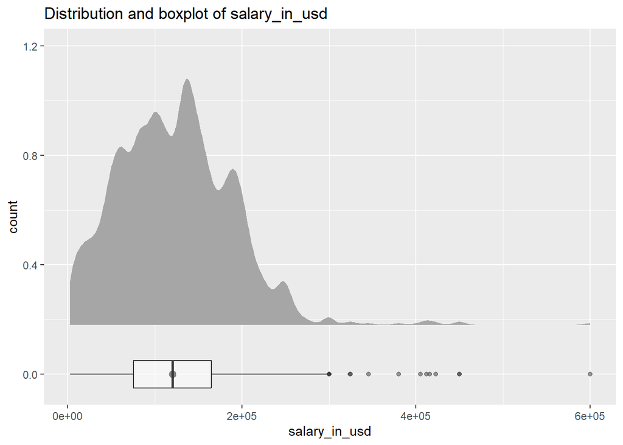

```r
ggplot(df, aes_string(x="salary_in_usd")) +
    ggdist::stat_halfeye(
      adjust=0.5,
      justification = -.2,
      .width=0
    ) +
    geom_boxplot(
      width = .1,
      alpha = 0.5
    ) +
     labs(title="Distribution and boxplot of salary_in_usd", y="count")
```

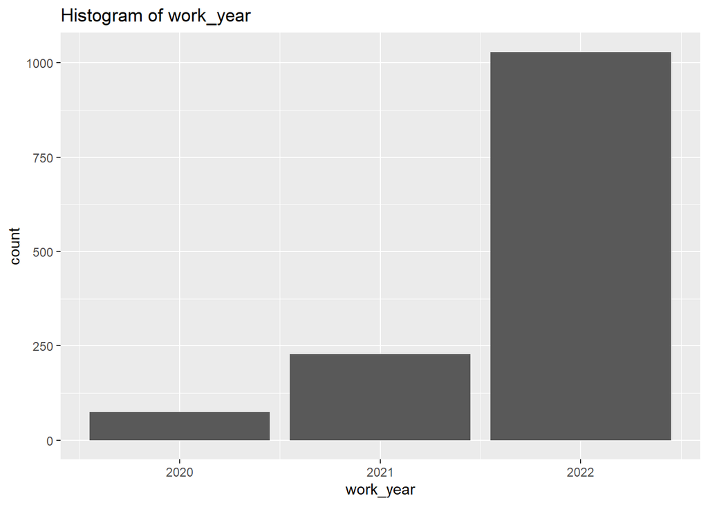

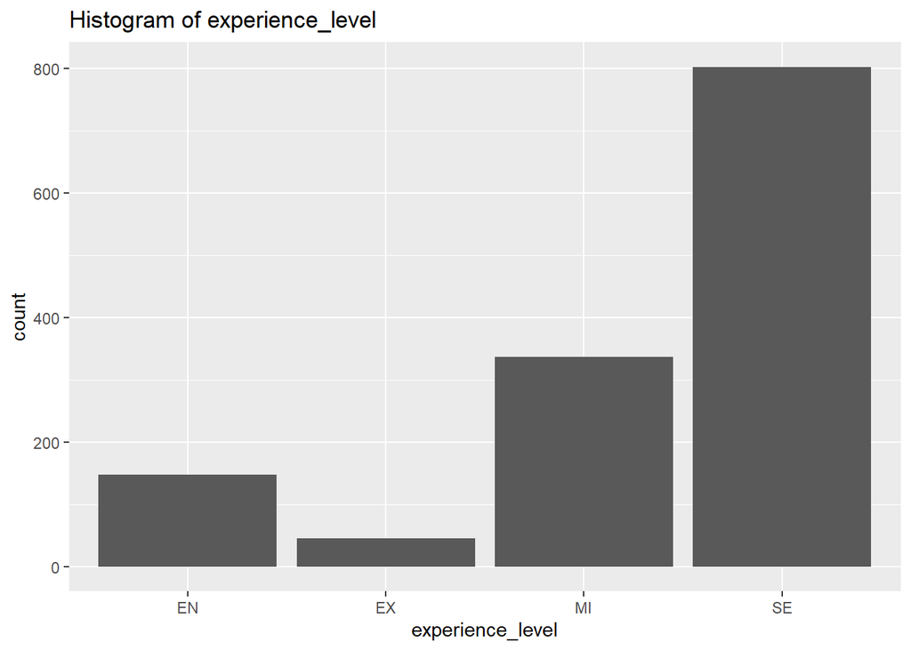

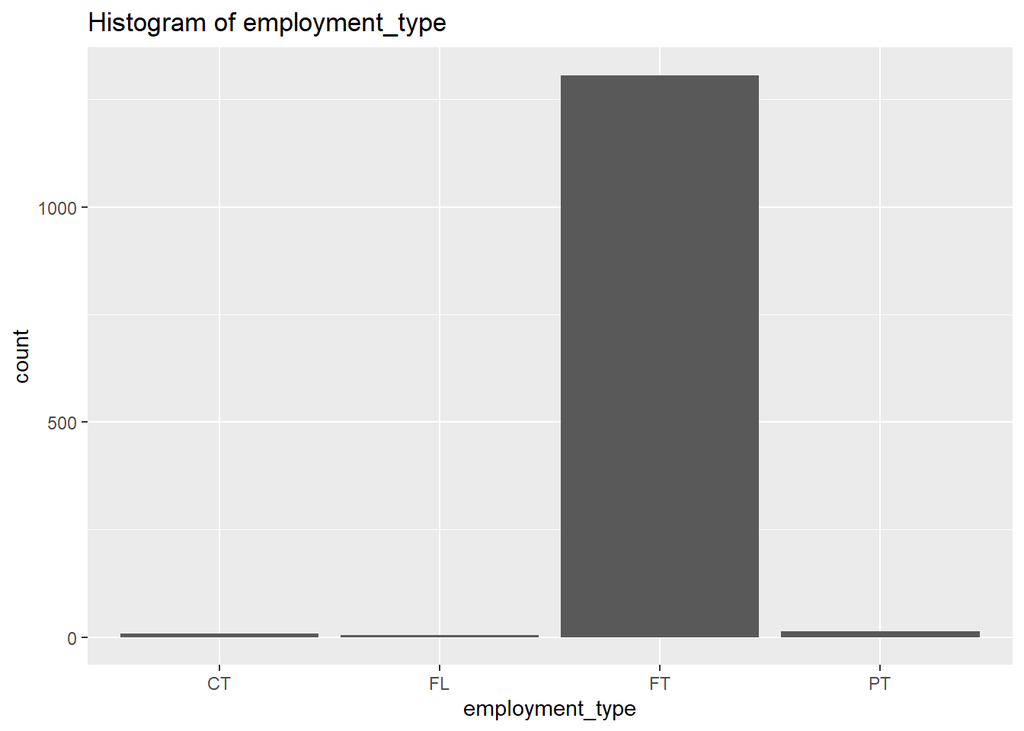

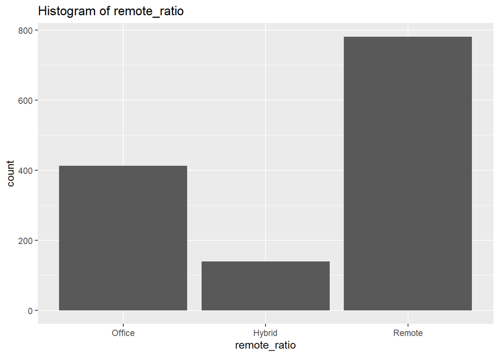

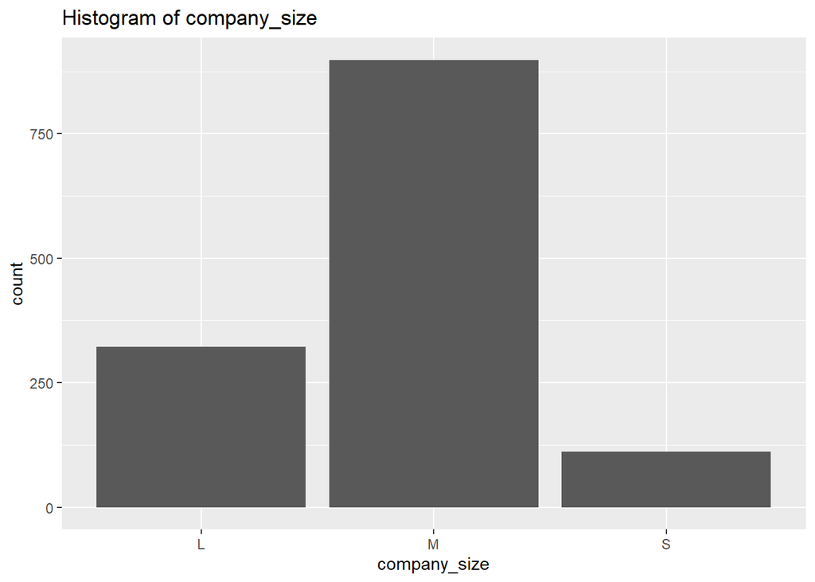

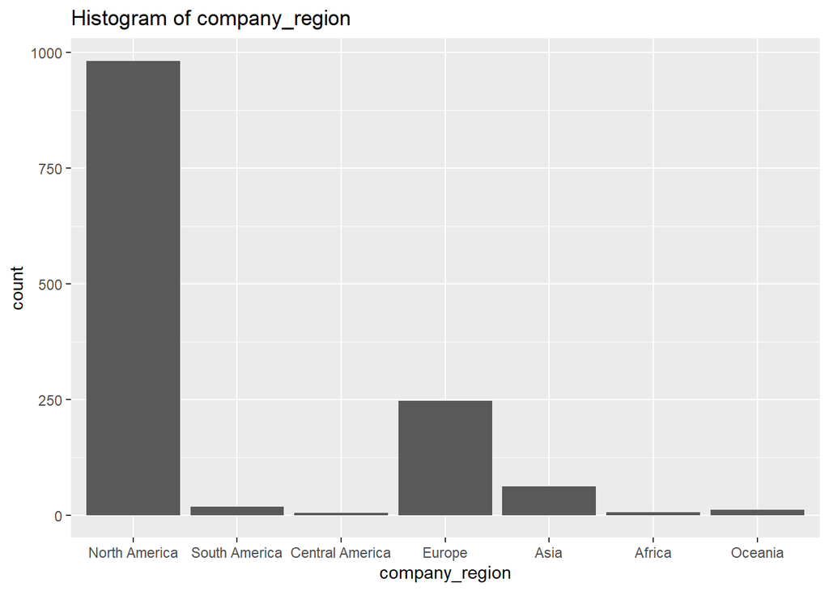

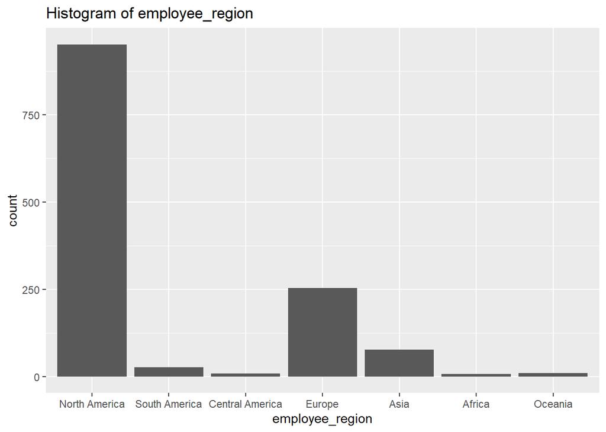

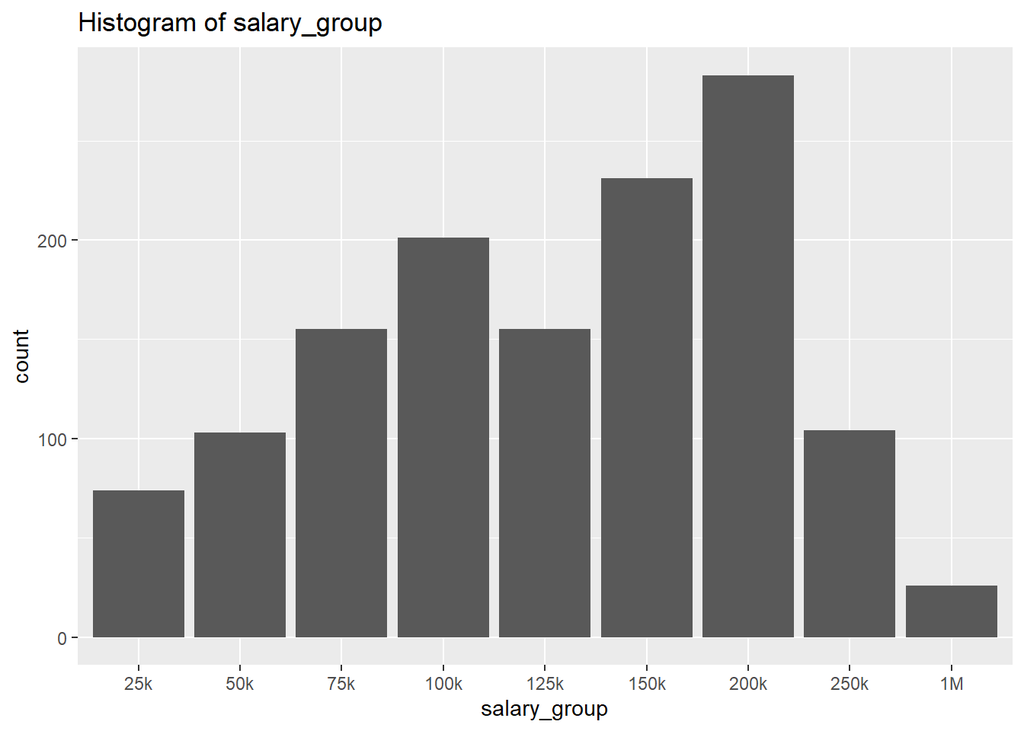

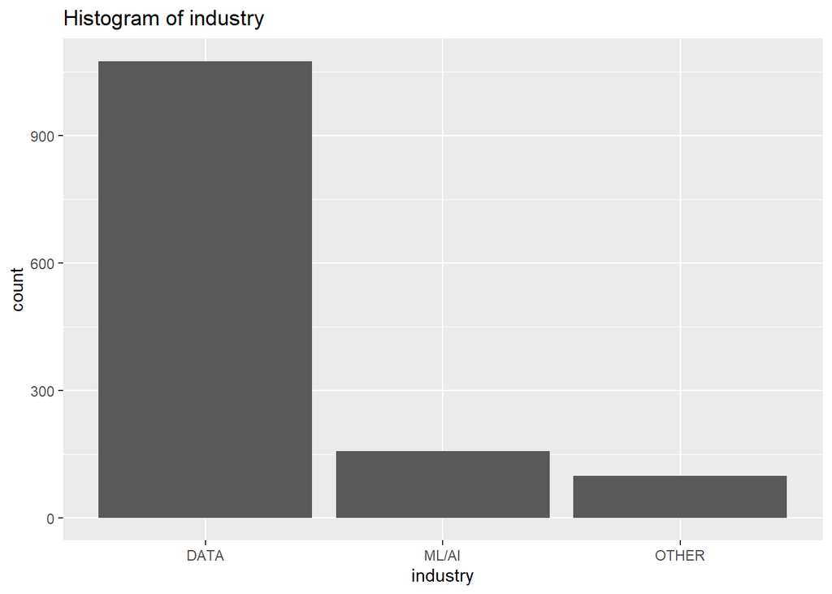

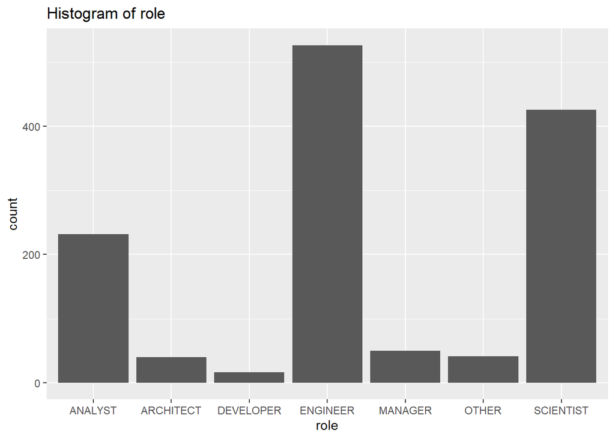

```r
factors_names <- c("work_year", "experience_level", "employment_type", "remote_ratio", "company_size", "company_region", "employee_region", "salary_group", "industry", "role")
for (i in 1:length(factors_names)){
  print(ggplot(df, aes_string(x= factors_names[i])) +
    geom_bar()+
     labs(title=paste("Histogram of",factors_names[i]),y="count"))
}
```

In these boxplots we can see that the salary may be conditioned by some attributes. Per example entry level employees earn less than executives

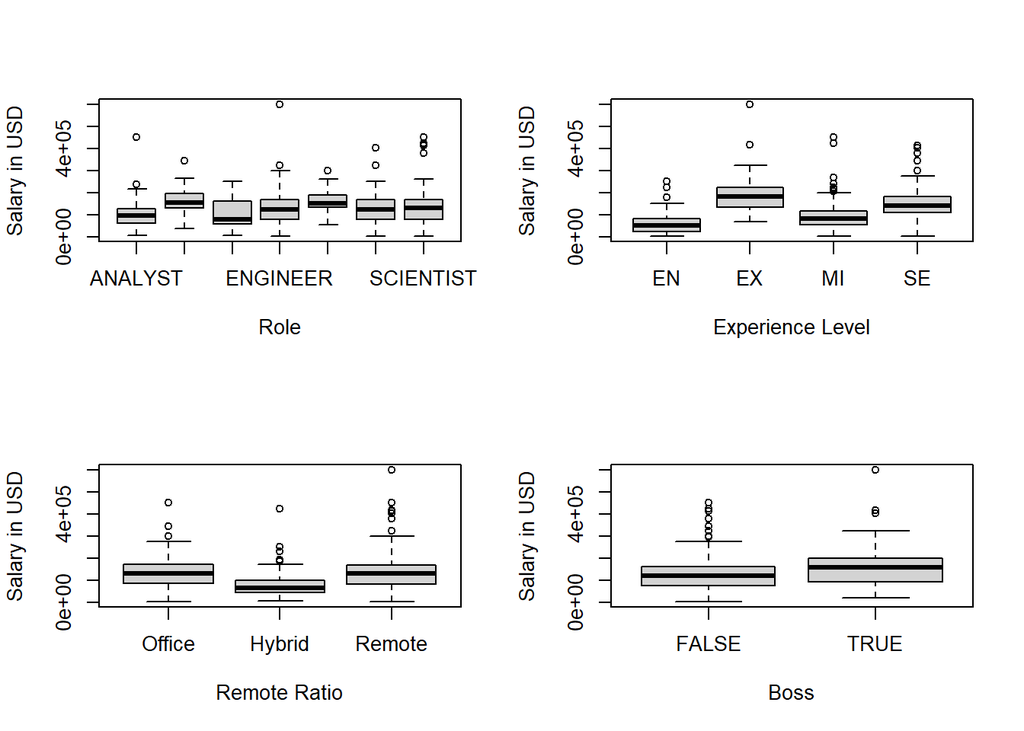

```r
par(mfrow = c(2,2))
p1 <- plot(df$role, df$salary_in_usd, xlab="Role", ylab="Salary in USD")
p2 <- plot(df$experience_level, df$salary_in_usd, xlab="Experience Level", ylab="Salary in USD")
p3 <- plot(df$remote_ratio, df$salary_in_usd, xlab="Remote Ratio", ylab="Salary in USD")
p4 <- plot(as.factor(df$boss), df$salary_in_usd, xlab="Boss", ylab="Salary in USD")
```

In this Sankey Diagram we can see the amount of people that live in a region and work for another region

```r
aux <- data.frame(matrix(0, nrow = length(levels(df$company_region)), ncol = length(levels(df$company_region))))
colnames(aux) <- levels(df$company_region)
rownames(aux) <- levels(df$company_region)

for (i in 1:nrow(aux)) {
  for (j in 1:ncol(aux)) {
    aux[i, j] <- length(which(df$company_region == colnames(aux)[j] & df$employee_region == rownames(aux)[i]))
  }
}

data_long <- aux %>%
  rownames_to_column %>%
  gather(key = 'key', value = 'value', -rowname) %>%
  filter(value > 0)
colnames(data_long) <- c("source", "target", "value")
data_long$target <- paste(data_long$target, " ", sep="")

nodes <- data.frame(name=c(as.character(data_long$source), as.character(data_long$target)) %>% unique())

data_long$IDsource=match(data_long$source, nodes$name)-1
data_long$IDtarget=match(data_long$target, nodes$name)-1

sankeyNetwork(Links = data_long, Nodes = nodes,
                     Source = "IDsource", Target = "IDtarget",
                     Value = "value", NodeID = "name",
                     sinksRight=FALSE, nodeWidth=30, fontSize=14, nodePadding=15)
```

[interactive chart not shown]

In this graph we can see that from the year 2021 to 2022 people stopped working Hybrid and they went to work from home or to the office.

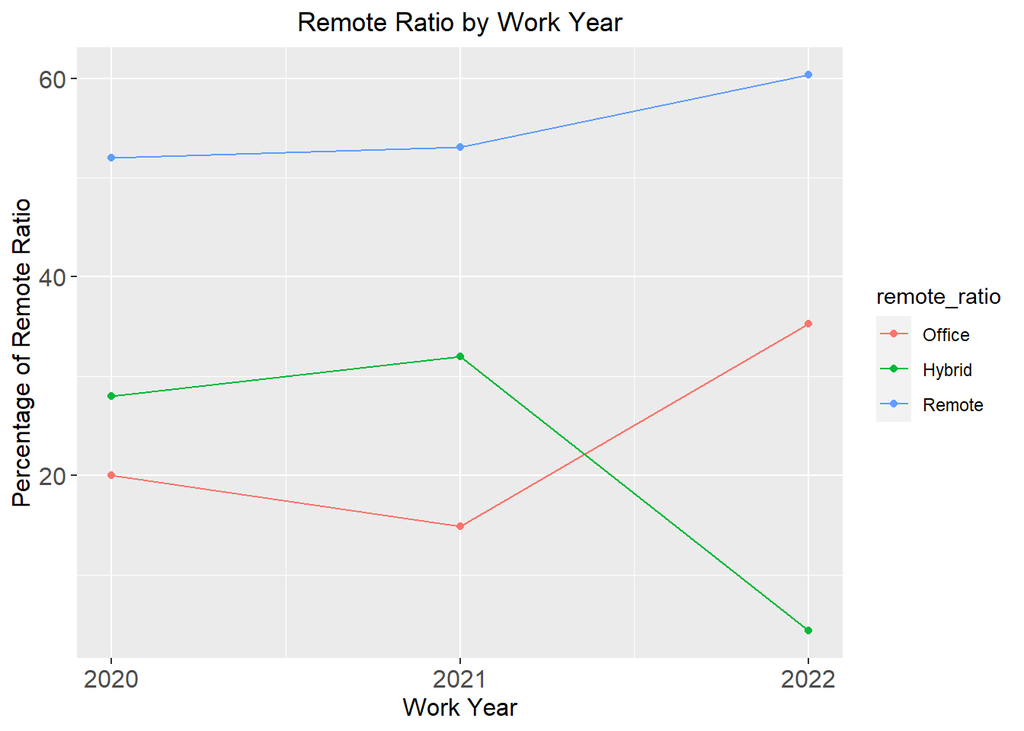

```r
y_2020 <- df[df$work_year == 2020,]
y_2021 <- df[df$work_year == 2021,]
y_2022 <- df[df$work_year == 2022,]

y_2020 <- y_2020 %>% group_by(remote_ratio) %>% summarise(count = n())
y_2021 <- y_2021 %>% group_by(remote_ratio) %>% summarise(count = n())
y_2022 <- y_2022 %>% group_by(remote_ratio) %>% summarise(count = n())

y_2020$percentage <- y_2020$count / sum(y_2020$count) * 100
y_2021$percentage <- y_2021$count / sum(y_2021$count) * 100
y_2022$percentage <- y_2022$count / sum(y_2022$count) * 100

y_2020$work_year <- 2020
y_2021$work_year <- 2021
y_2022$work_year <- 2022

y <- rbind(y_2020, y_2021, y_2022)

ggplot(y, aes(x = work_year, y = percentage, group = remote_ratio, color = remote_ratio)) +
  geom_line()+
  geom_point() +
  labs(x = "Work Year", y = "Percentage of Remote Ratio", title = "Remote Ratio by Work Year") +
  theme(plot.title = element_text(hjust = 0.5), axis.text=element_text(size=12),
        axis.title=element_text(size=12)) +
  scale_x_continuous(breaks = c(2020, 2021, 2022))
```

# Part 2: Context of the problem, Models and Evaluation

## Research Questions

### 1. Profile-based prediction and maximization of compensation

```r
#First we remove some columns that wont bring useful information to the model:

dfTreeRegression <- df
dfTreeRegression$salary_currency <- NULL

#We are going to try to predict salary with a regression tree. We are going to eliminate the created "salary_group" column because otherwise it would be kinda cheating since its the value that we are trying to predict.

dfTreeRegression$salary_group <- NULL

#After making a couple of tests, we saw that these variables are never used by the tree to make predictions, so we are going to remove them from the set so getting the best options for our profiles is easier later:

dfTreeRegression$company_region <- NULL
dfTreeRegression$employee_region <- NULL
dfTreeRegression$work_year <- NULL
dfTreeRegression$research <- NULL
dfTreeRegression$employment_type <- NULL
dfTreeRegression$role <- NULL
dfTreeRegression$boss <- NULL

set.seed(42)
sample <- sample(c(TRUE, FALSE), nrow(dfTreeRegression), replace=TRUE, prob=c(0.8,0.2))
Tree_train  <- dfTreeRegression[sample, ]
Tree_test   <- dfTreeRegression[!sample, ]
```

#### 1.1 Model

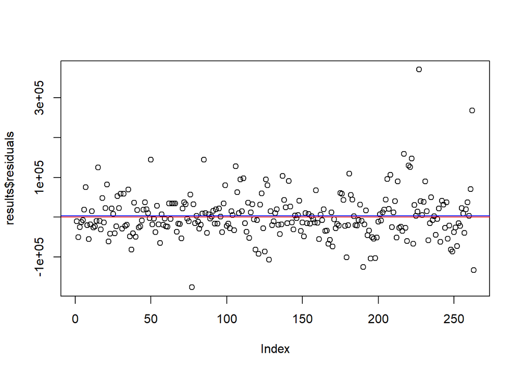

```r
#Con el parametro "cp", cuanto mas proximo a 0, menos poda hace.
fit <- rpart(salary_in_usd~., data = Tree_train, method="anova", control = list(cp = 0.0001))
rules <- rpart.rules(fit)

test_pred <- predict(fit, Tree_test, method="anova")
results <- data.frame(test_pred, Tree_test$salary_in_usd)
results$residuals <- results$Tree_test.salary_in_usd-results$test_pred
plot(results$residuals)
abline(0,0, col="red")
resmean <- mean(results$residuals)
abline(resmean,0, col="blue")
```

```r
sd(results$residuals)
```

```
## [1] 57435.01
```

```r
nrow(rules)
```

```
## [1] 51
```

#### 1.2 Salary Prediction

```r
datos_monica <- Tree_test[1,]
datos_monica[1,] = list("MI", "Data Scientist",0, "ES", "Hybrid", "ES", "S", "DATA")
options(width=1000)

salarios = rpart.predict(fit, datos_monica)
salarios
```

```
##        1
## 40856.43
```

#### 1.3 Salary Maximization

```r
wallis_grid <- expand.grid(
  experience_level = c("EN"),
  job_title = c("ML Engineer"),
  salary_in_usd = 0,
  employee_residence = c("US"),
  remote_ratio = levels(df$remote_ratio),
  company_location = c("US"),
  company_size = levels(df$company_size),
  industry = c("ML/AI")
)
head(wallis_grid)
```

```
##   experience_level   job_title salary_in_usd employee_residence remote_ratio company_location company_size industry
## 1               EN ML Engineer             0                 US       Office               US            L    ML/AI
## 2               EN ML Engineer             0                 US       Hybrid               US            L    ML/AI
## 3               EN ML Engineer             0                 US       Remote               US            L    ML/AI
## 4               EN ML Engineer             0                 US       Office               US            M    ML/AI
## 5               EN ML Engineer             0                 US       Hybrid               US            M    ML/AI
## 6               EN ML Engineer             0                 US       Remote               US            M    ML/AI
```

```r
prediction <- rpart.predict(fit, wallis_grid)
wallis_max <- max(prediction)
wallis_best_combinations_index <- which(wallis_max == prediction)
wallis_best_combinations <- wallis_grid[wallis_best_combinations_index,]
wallis_best_combinations
```

```
##   experience_level   job_title salary_in_usd employee_residence remote_ratio company_location company_size industry
## 4               EN ML Engineer             0                 US       Office               US            M    ML/AI
## 5               EN ML Engineer             0                 US       Hybrid               US            M    ML/AI
## 6               EN ML Engineer             0                 US       Remote               US            M    ML/AI
## 7               EN ML Engineer             0                 US       Office               US            S    ML/AI
## 8               EN ML Engineer             0                 US       Hybrid               US            S    ML/AI
## 9               EN ML Engineer             0                 US       Remote               US            S    ML/AI
```

```r
wallis_max
```

```
## [1] 102330.8
```

```r
dawid_grid <- expand.grid(
  experience_level = c("MI"),
  job_title = c("ML Engineer"),
  salary_in_usd = 0,
  employee_residence = c("ES"),
  remote_ratio = c("Remote"),
  company_location = levels(df$company_location),
  company_size = levels(df$company_size),
  industry = c("ML/AI")
)
head(dawid_grid)
```

```
##   experience_level   job_title salary_in_usd employee_residence remote_ratio company_location company_size industry
## 1               MI ML Engineer             0                 ES       Remote               AE            L    ML/AI
## 2               MI ML Engineer             0                 ES       Remote               AL            L    ML/AI
## 3               MI ML Engineer             0                 ES       Remote               AR            L    ML/AI
## 4               MI ML Engineer             0                 ES       Remote               AS            L    ML/AI
## 5               MI ML Engineer             0                 ES       Remote               AT            L    ML/AI
## 6               MI ML Engineer             0                 ES       Remote               AU            L    ML/AI
```

```r
prediction <- rpart.predict(fit, dawid_grid)
dawid_max <- max(prediction)
dawid_best_combinations_index <- which(dawid_max == prediction)
dawid_best_combinations <- dawid_grid[dawid_best_combinations_index,]
dawid_best_combinations
```

```
##     experience_level   job_title salary_in_usd employee_residence remote_ratio company_location company_size industry
## 1                 MI ML Engineer             0                 ES       Remote               AE            L    ML/AI
## 5                 MI ML Engineer             0                 ES       Remote               AT            L    ML/AI
## 7                 MI ML Engineer             0                 ES       Remote               BE            L    ML/AI
## 13                MI ML Engineer             0                 ES       Remote               CN            L    ML/AI
## 18                MI ML Engineer             0                 ES       Remote               DZ            L    ML/AI
## 22                MI ML Engineer             0                 ES       Remote               FI            L    ML/AI
## 24                MI ML Engineer             0                 ES       Remote               GB            L    ML/AI
## 33                MI ML Engineer             0                 ES       Remote               IQ            L    ML/AI
## 36                MI ML Engineer             0                 ES       Remote               JP            L    ML/AI
## 52                MI ML Engineer             0                 ES       Remote               RU            L    ML/AI
## 54                MI ML Engineer             0                 ES       Remote               SI            L    ML/AI
## 58                MI ML Engineer             0                 ES       Remote               US            L    ML/AI
## 60                MI ML Engineer             0                 ES       Remote               AE            M    ML/AI
## 64                MI ML Engineer             0                 ES       Remote               AT            M    ML/AI
```

[output cut: 22 more lines]

```r
dawid_max
```

```
## [1] 109338.5
```

### 2. How can data mining techniques be used to identify which employees are at risk of leaving their company?

This could be useful for companies who want to retain their top talent and for employees that are underpaid. We could use different factors such to determine which employees are underpaid compared to their peers.

To answer this questions we will use two different techniques: Clustering and regression.

The following features will be used:

- Experience level
- Employment type
- Industry
- Employee region
- Company region
- Role
- Remote_ratio
- Boss
- Research
- Company size

#### 2.1 Clustering

First we create a separate dataframe for the variables we will use.

```r
# Select the variables to use in the clustering analysis
df_vars <- dplyr::select(df, experience_level, employment_type, company_size, industry, employee_region, company_region, boss, research, role, remote_ratio)
```

Lets find find the elbow in our plot, to find the “best” k for the kmodes algorithm

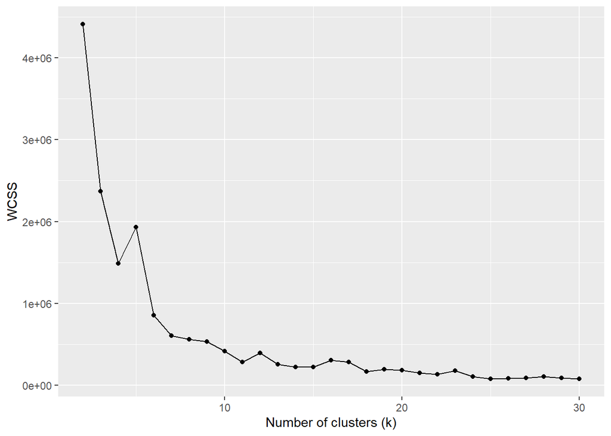

```r
results <- data.frame(k = integer(), WCSS = double())

# Loop through a range of values for k
for (k in 2:30) {
  # Run the k-means clustering algorithm
  km <- kmodes(df_vars, k, iter.max = 25)
  # Store the results in the data frame
  results <- rbind(results, data.frame(k = k, WCSS = sum(km$withindiff^2)))
}

# Plot the WCSS values for each value of k
ggplot(results, aes(x = k, y = WCSS)) +
  geom_line() +
  geom_point() +
  labs(x = "Number of clusters (k)", y = "WCSS")
```

```r
# Perform k-means clustering with n clusters
kmodes_results <- kmodes(df_vars, 20)

df_Q7 <- df

# Add the cluster labels to the original data
df_Q7$cluster <- kmodes_results$cluster

group_by(df_Q7, cluster) %>%
  summarize(mean_salary = mean(salary_in_usd))
```

```
## # A tibble: 20 × 2
##    cluster mean_salary
##      <int>       <dbl>
##  1       1      94910.
##  2       2     153549.
##  3       3      51639.
##  4       4     146121.
##  5       5     130074.
##  6       6     126321.
##  7       7     104099.
##  8       8      27411.
##  9       9      75400.
## 10      10     162846.
## 11      11     154638.
## 12      12      61648.
## 13      13      56848.
## 14      14     152192.
## 15      15      68860.
## 16      16      61150.
## 17      17      64550.
## 18      18      98655.
## 19      19      84373.
## 20      20      59200.
```

```r
mean_salary <- tapply(df_Q7$salary_in_usd, df_Q7$cluster, mean)

# Calculate the difference between the real salary and the mean salary of the cluster that the employee pertains to
df_Q7$salary_difference_kmodes <- 0
df_Q7$predicted_salary_kmodes <-0

for (i in 1:nrow(df_Q7)) {
  cluster_index = match(df_Q7$cluster[i], names(mean_salary))
  df_Q7$salary_difference_kmodes[i] <- df_Q7$salary_in_usd[i] - mean_salary[cluster_index]
  df_Q7$predicted_salary_kmodes[i] <- mean_salary[cluster_index]
}
```

#### 2.2 Multi Lineal Regression

The lineal model that we will use is quite simple, with out using combination of variables we will stick to a base model.

```r
model <- lm(salary_in_usd ~ experience_level + employment_type + employee_region + company_size + industry + role + boss + research + remote_ratio + company_region, data = df_Q7)
summary(model)
```

```
##
## Call:
## lm(formula = salary_in_usd ~ experience_level + employment_type +
##     employee_region + company_size + industry + role + boss +
##     research + remote_ratio + company_region, data = df_Q7)
##
## Residuals:
##     Min      1Q  Median      3Q     Max
## -143436  -27780   -4536   24378  359195
##
## Coefficients:
##                                  Estimate Std. Error t value Pr(>|t|)
## (Intercept)                     116265.15   19486.15   5.967 3.12e-09 ***
## experience_levelEX               89098.24    9292.32   9.588  < 2e-16 ***
## experience_levelMI               20434.34    5090.91   4.014 6.31e-05 ***
## experience_levelSE               42910.47    5106.69   8.403  < 2e-16 ***
## employment_typeFL               -67709.64   28880.51  -2.344 0.019204 *
## employment_typeFT               -30157.66   18601.04  -1.621 0.105198
## employment_typePT               -30582.70   23271.34  -1.314 0.189018
## employee_regionSouth America    -58298.41   17475.53  -3.336 0.000874 ***
## employee_regionCentral America  -18630.53   28918.94  -0.644 0.519538
## employee_regionEurope           -52422.90   11502.82  -4.557 5.67e-06 ***
## employee_regionAsia             -57038.61   13088.82  -4.358 1.42e-05 ***
## employee_regionAfrica          -112061.00   53414.66  -2.098 0.036103 *
## employee_regionOceania          -26328.37   39962.38  -0.659 0.510122
## company_sizeM                    -4416.80    3474.42  -1.271 0.203873
## company_sizeS                   -13522.92    5533.97  -2.444 0.014673 *
## industryML/AI                    12440.80    4500.74   2.764 0.005787 **
## industryOTHER                      -75.45    6405.74  -0.012 0.990604
## roleARCHITECT                    41944.04    8362.51   5.016 6.02e-07 ***
## roleDEVELOPER                    22816.85   13452.69   1.696 0.090110 .
## roleENGINEER                     27939.89    4050.11   6.899 8.18e-12 ***
## roleMANAGER                      41123.32    7675.31   5.358 9.95e-08 ***
## roleOTHER                        14262.67    9409.13   1.516 0.129805
## roleSCIENTIST                    32195.28    4029.57   7.990 2.96e-15 ***
## bossTRUE                         39442.59    7833.24   5.035 5.44e-07 ***
## researchTRUE                      7014.16   11527.84   0.608 0.542993
## remote_ratioHybrid               -9123.57    5383.17  -1.695 0.090347 .
## remote_ratioRemote               -1783.28    2997.36  -0.595 0.551982
## company_regionSouth America     -26064.49   20904.60  -1.247 0.212685
## company_regionCentral America    12444.21   36122.68   0.344 0.730527
## company_regionEurope            -12107.16   11484.18  -1.054 0.291966
## company_regionAsia              -26317.14   14035.96  -1.875 0.061020 .
## company_regionAfrica             70488.34   57003.56   1.237 0.216474
## company_regionOceania            -8815.69   36795.69  -0.240 0.810690
## ---
## Signif. codes:  0 '***' 0.001 '**' 0.01 '*' 0.05 '.' 0.1 ' ' 1
##
## Residual standard error: 48320 on 1299 degrees of freedom
## Multiple R-squared:  0.476,  Adjusted R-squared:  0.4631
## F-statistic: 36.87 on 32 and 1299 DF,  p-value: < 2.2e-16
```

```r
df_Q7$predicted_salary_lm  <- predict(model, newdata = df_Q7)
df_Q7$salary_difference_lm <- df_Q7$salary_in_usd - df_Q7$predicted_salary_lm
```

#### 2.3 Results

Once we have the salary difference between the predicted salary using both methods we will calculate the percentage error.

Then we will partition the data entries into 3 groups depending on the error of the prediction. Underpaid, Normal and Overpaid

```r
df_Q7$kmodes_ratio_error <- ((df_Q7$predicted_salary_kmodes / df_Q7$salary_in_usd)-1)*100
df_Q7$lm_ratio_error <- ((df_Q7$predicted_salary_lm / df_Q7$salary_in_usd)-1)*100

summary(df_Q7[, c("kmodes_ratio_error","lm_ratio_error")])
```

```
##  kmodes_ratio_error lm_ratio_error
##  Min.   : -78.909   Min.   :-277.391
##  1st Qu.: -19.036   1st Qu.: -17.608
##  Median :   4.056   Median :   3.971
##  Mean   :  51.872   Mean   :  32.111
##  3rd Qu.:  39.859   3rd Qu.:  31.420
##  Max.   :6606.986   Max.   :4279.650
```

```r
quantiles_kmodes <- quantile(df_Q7$kmodes_ratio_error, c(0.25,0.75))
quantiles_lm <- quantile(df_Q7$lm_ratio_error, c(0.25,0.75))
```

```r
df_Q7 <- df_Q7[order(df_Q7$salary_in_usd),]
x <- 1:nrow(df_Q7)

df_Q7$status_lm <- ifelse(df_Q7$lm_ratio_error < quantiles_kmodes[1], "Overpaid",
                      ifelse(df_Q7$lm_ratio_error < quantiles_kmodes[2], "Normal", "Underpaid"))

df_Q7$status_kmodes <- ifelse(df_Q7$kmodes_ratio_error < quantiles_lm[1], "Overpaid",
                      ifelse(df_Q7$kmodes_ratio_error < quantiles_lm[2], "Normal", "Underpaid"))
```

Once we have this three groups we can plot the predicted salary versus the real salary using. We’ve colored the predicted salary depening on the consideration.

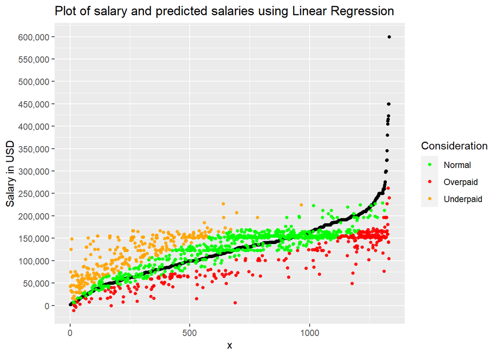

```r
ggplot(df_Q7, aes(x = x, y = salary_in_usd)) +
        geom_point(aes(y = salary_in_usd), size= 2, shape = 20) +
        geom_point(aes(y = predicted_salary_lm, color = status_lm), size =2,  shape = 20, alpha = 0.9) +
        scale_color_manual(
          values = c("Overpaid" = "red", "Underpaid" = "orange", "Normal" = "green"),
          labels = c('Normal', 'Overpaid', 'Underpaid'),
          aesthetics = c("colour", "fill"),
          name = "Consideration") +
        ggtitle("Plot of salary and predicted salaries using Linear Regression") +
        ylab("Salary in USD") +
        scale_y_continuous(labels = label_comma(), breaks = scales::pretty_breaks(n = 10))
```

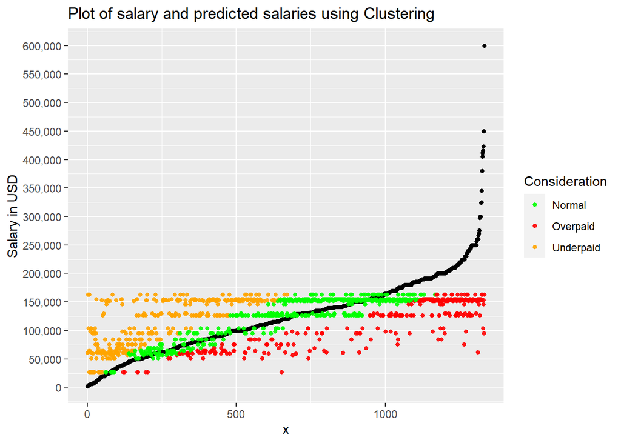

```r
ggplot(df_Q7, aes(x = x, y = salary_in_usd)) +
        geom_point(aes(y = salary_in_usd), size= 2, shape = 20) +
        geom_point(aes(y = predicted_salary_kmodes, color = status_kmodes), size =2,  shape = 20, alpha = 0.9) +
        scale_color_manual(
          values = c("Overpaid" = "red", "Underpaid" = "orange", "Normal" = "green"),
          labels = c('Normal', 'Overpaid', 'Underpaid'),
          aesthetics = c("colour", "fill"),
          name = "Consideration") +
        ggtitle("Plot of salary and predicted salaries using Clustering") +
        ylab("Salary in USD") +
        labs(fill="Consideration") +
        scale_y_continuous(labels = label_comma(), breaks = scales::pretty_breaks(n = 10))
```

In this heatmap we can see the difference between the consideration of both models. As we see they mostly “agree” with each other

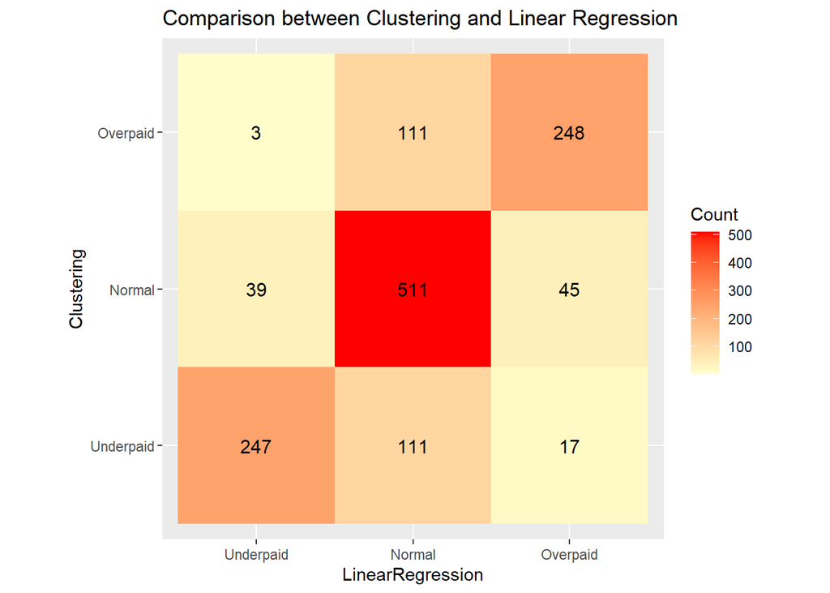

```r
df_Q7$status_lm <- as.factor(df_Q7$status_lm)
df_Q7$status_kmodes <- as.factor(df_Q7$status_kmodes)

ct <- table(df_Q7$status_lm,df_Q7$status_kmodes)
ct <- ct[c(3,1,2),c(3,1,2)]
ct <- melt(ct)
colnames(ct) <- c("LinearRegression", "Clustering", "Count")

ggplot(ct, aes(x = LinearRegression, y = Clustering, fill = Count)) +
  geom_tile() +
  scale_fill_gradient2(low = "#075AFF", mid = "#FFFFCC", high = "#FF0000") +
  geom_text(aes(label = Count), color = "black", size = 4) +
  coord_fixed() +
  ggtitle("Comparison between Clustering and Linear Regression")
```

```r
underpaid_lm <- df_Q7[df_Q7$status_lm=="Underpaid",]
overpaid_lm <- df_Q7[df_Q7$status_lm=="Overpaid",]

underpaid_kmodes <- df_Q7[df_Q7$status_kmodes =="Underpaid",]
overpaid_kmodes  <- df_Q7[df_Q7$status_kmodes =="Overpaid",]
```

In this graph we can see the different distribution of the experience level and role attributes amongst the three “fairness” consideration.

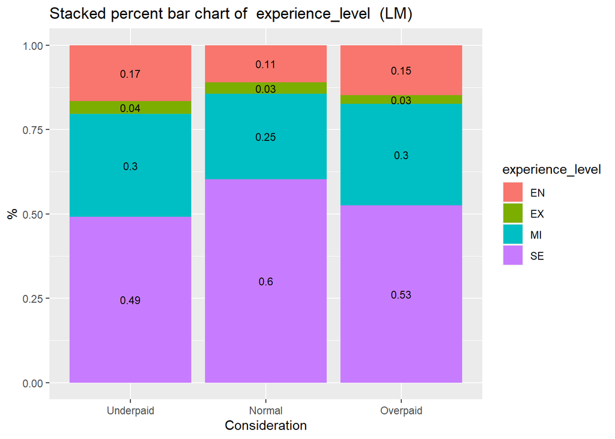

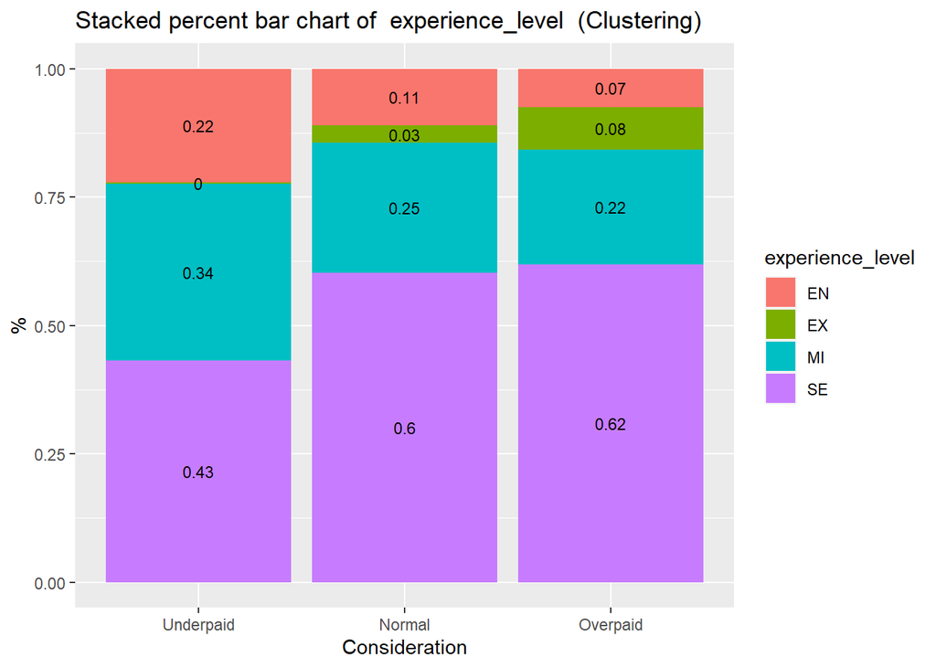

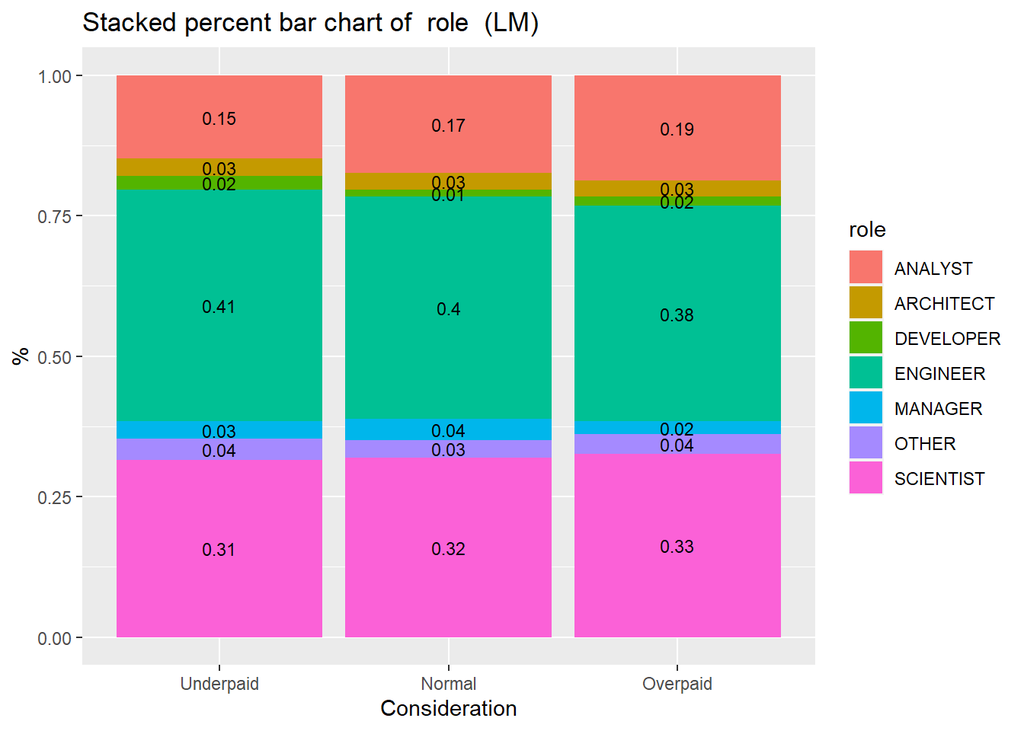

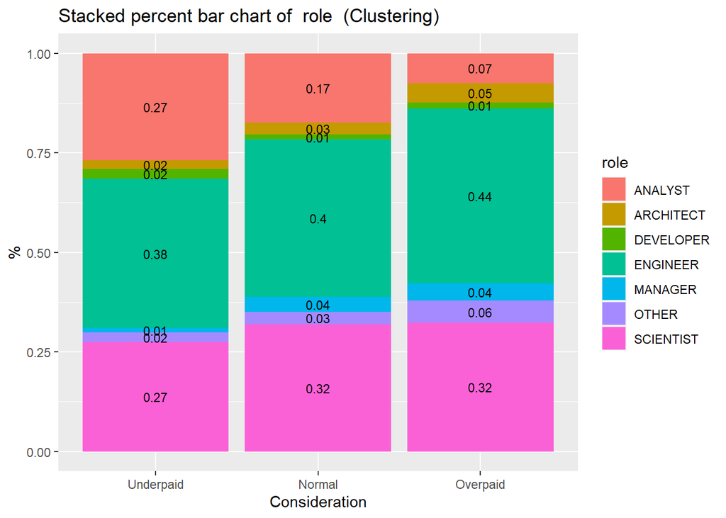

```r
variables <- c("experience_level", "role")

for (i in 1:length(variables)){
  ratio_df <- table(df_Q7[, c(variables[i])])/nrow(df_Q7)
  ratio_up_lm <- table(underpaid_lm[, c(variables[i])])/nrow(underpaid_lm)
  ratio_op_lm <- table(overpaid_lm[, c(variables[i])])/nrow(overpaid_lm)

  # plot them in such a way that they can be compared
  df_long_lm <- melt(data.frame(ratio_up_lm, ratio_df, ratio_op_lm))

  ratio_up_kmodes <- table(underpaid_kmodes[, c(variables[i])])/nrow(underpaid_kmodes)
  ratio_op_kmodes <- table(overpaid_kmodes[, c(variables[i])])/nrow(overpaid_kmodes)

  # plot them in such a way that they can be compared
  df_long_kmodes <- melt(data.frame(ratio_up_kmodes, ratio_df, ratio_op_kmodes))

  print(ggplot(data = df_long_lm, aes(x = variable, y = value , fill = Var1, label = round(value, 2))) +
    geom_bar(stat = "identity", position = "fill") +
    geom_text(size = 3, position = position_stack(vjust = 0.5)) +
    scale_x_discrete(labels = c("Freq"= "Underpaid", "Freq.1"= "Normal", "Freq.2" = "Overpaid")) +
    labs(fill=variables[i], title=paste("Stacked percent bar chart of ",variables[i], " (LM)"), x="Consideration", y = "%"))

   print(ggplot(data = df_long_kmodes, aes(x = variable, y = value , fill = Var1, label = round(value, 2))) +
    geom_bar(stat = "identity", position = "fill") +
    geom_text(size = 3, position = position_stack(vjust = 0.5)) +
    scale_x_discrete(labels = c("Freq"= "Underpaid", "Freq.1"= "Normal", "Freq.2" = "Overpaid")) +
    labs(fill=variables[i], title=paste("Stacked percent bar chart of ",variables[i], " (Clustering)"), x="Consideration", y = "%"))
}
```

### 3. Employee Seniority: Upward mobility and career growth

#### 3.1 Decision Tree

Can we predict an employee’s experience level based on their salary and job title? Using classification algorithms, we could build a model that predicts an employee’s experience level based on their salary and job title. This could be useful for employees and job seekers who want to understand what experience level they can expect to be paid for a given salary and job title. We could also include other factors, such as location and company size, to improve the accuracy of the model.

For this we’ll use a Decision Tree since we are interested in having a clear way to visualize and understand the result. We want to classify the experience level of employees based on attributes such as their role, industry for which they work, salary, etcetera.

BASE MODEL: Predict experience level with only salary and job title; since job title is a factor with numerous levels industry and role will be used instead.

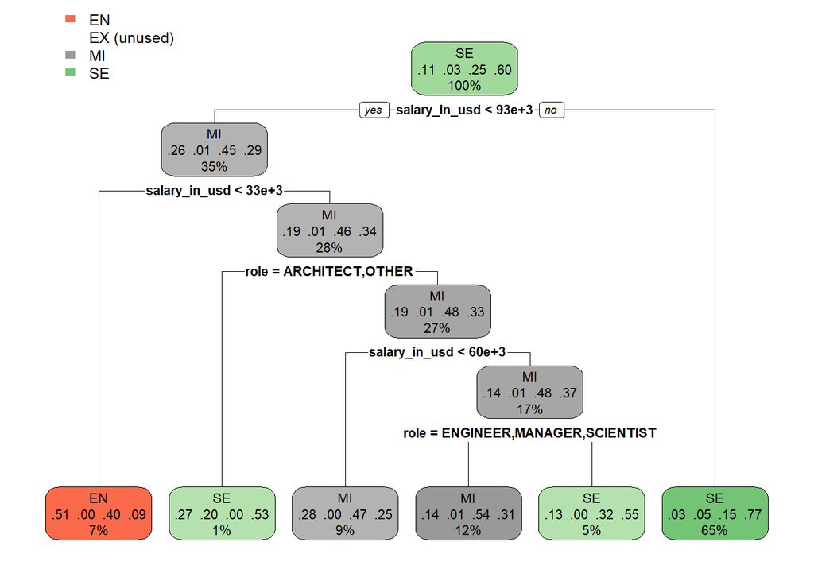

```r
df14 = df[, c("industry", "role", "salary_in_usd", "experience_level")]
dt14 = rpart(experience_level~., data=df14)
rpart.plot(dt14)
```

ADVANCED MODEL: Predict experience level with all of the variables available (apart from those which factor level exceeds 32).

```r
df14v2 = df[ , -which(names(df) %in% c("job_title", "work_year", "ID", "company_location", "employee_residence", "employee_region", "company_region", "salary_group", "salary_currency", "remote_ratio"))]
summary(df14v2)
```

```
##  experience_level employment_type salary_in_usd    company_size  industry           role        boss          research
##  EN:147           CT:   8         Min.   :  2324   L:322        DATA :1076   ANALYST  :232   Mode :logical   Mode :logical
##  EX: 45           FL:   5         1st Qu.: 75593   M:898        ML/AI: 157   ARCHITECT: 40   FALSE:1276      FALSE:1306
##  MI:337           FT:1306         Median :120000   S:112        OTHER:  99   DEVELOPER: 16   TRUE :56        TRUE :26
##  SE:803           PT:  13         Mean   :123375                             ENGINEER :527
##                                   3rd Qu.:164997                             MANAGER  : 50
##                                   Max.   :600000                             OTHER    : 41
##                                                                              SCIENTIST:426
```

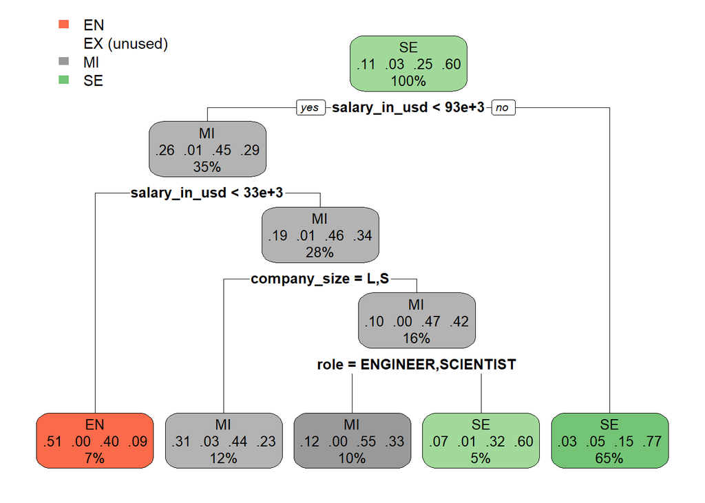

```r
dt14v2 = rpart(experience_level~., data=df14v2)
rpart.plot(dt14v2)
```

#### 3.2 K-NN

How accurately can we predict experience_level within the company using a k-nearest neighbors classification model, while excluding the salary attribute from the dataset?

we first create a dataset without the salary variables, and partition it into a 70% train and test subset.

```r
set.seed(123)
df_no_s <- df
df_no_s$salary_group <- NULL
df_no_s$salary_currency <- NULL
df_no_s$salary_in_usd <- NULL
train_index <- createDataPartition(df_no_s$experience_level, p = 0.7, list = FALSE)
train_data <- df_no_s[train_index, ]
test_data <- df_no_s[-train_index, ]
```

We then create and train the knn model, with k’s from 1 to 20.

```r
model <- train(experience_level ~ ., data = train_data, method = "knn", tuneGrid = expand.grid(k = 1:20))
```

```r
print(model$bestTune$k)
```

```
## [1] 1
```

```r
summary(model)
```

```
##             Length Class      Mode
## learn         2    -none-     list
## k             1    -none-     numeric
## theDots       0    -none-     list
## xNames      214    -none-     character
## problemType   1    -none-     character
## tuneValue     1    data.frame list
## obsLevels     4    -none-     character
## param         0    -none-     list
```

As we can see the best results where obtained when k=1. Now we can proceed to check which variables are more important in the model to determine the experience level.

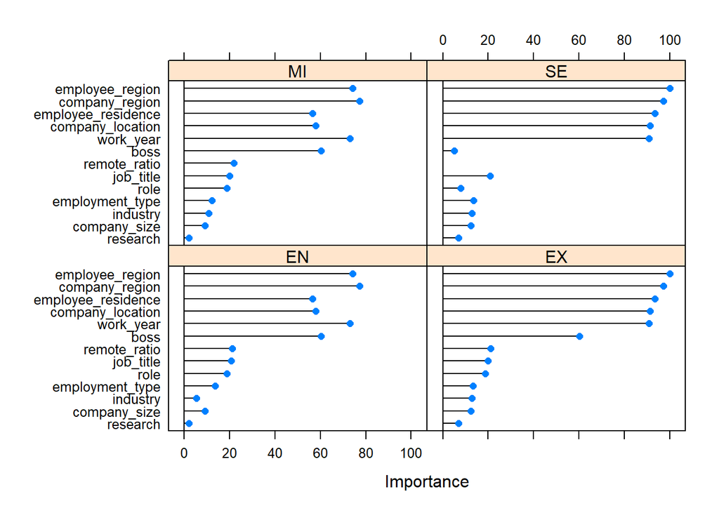

```r
importance <- varImp(model)
plot(importance)
```

```r
predictions <- predict(model, test_data)
cMatrix <- confusionMatrix(predictions, test_data$experience_level)
```

## Discarded Questions

### 1. How much should the salary increase be when you get promoted to a higher Experience Level?

This could be useful for employees that are going to recieve a promotion, and want to know how much they should get paid for their new position. It could also be useful for employers that want to know how much they should offer new hires or promoting employees.

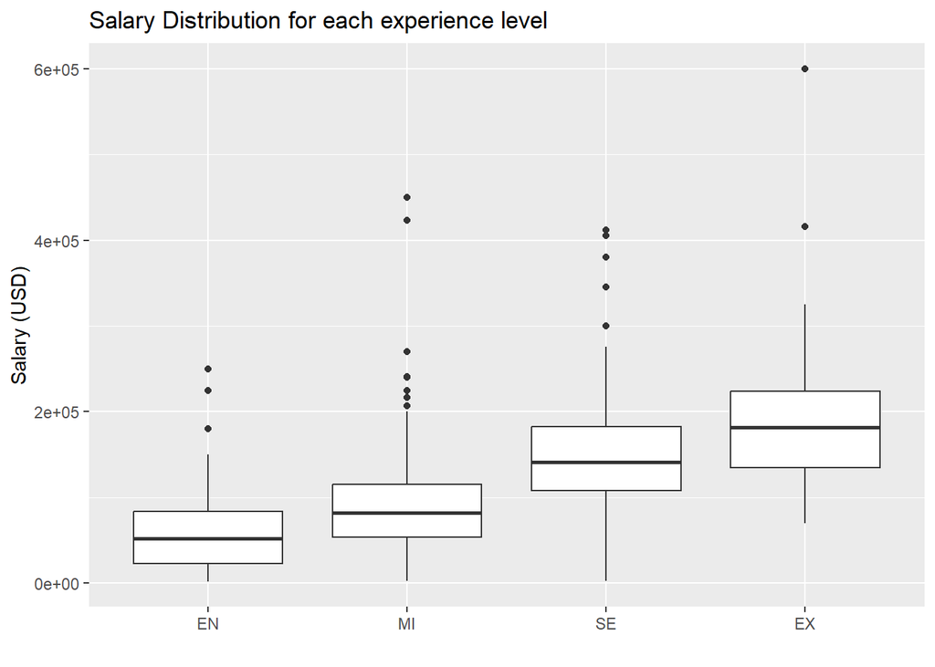

```r
f <- ggplot(df, aes(x=reorder(experience_level,salary_in_usd), y=salary_in_usd))+
     geom_boxplot()+
     ggtitle("Salary Distribution for each experience level") + ylab("Salary (USD)") + xlab("")
f
```

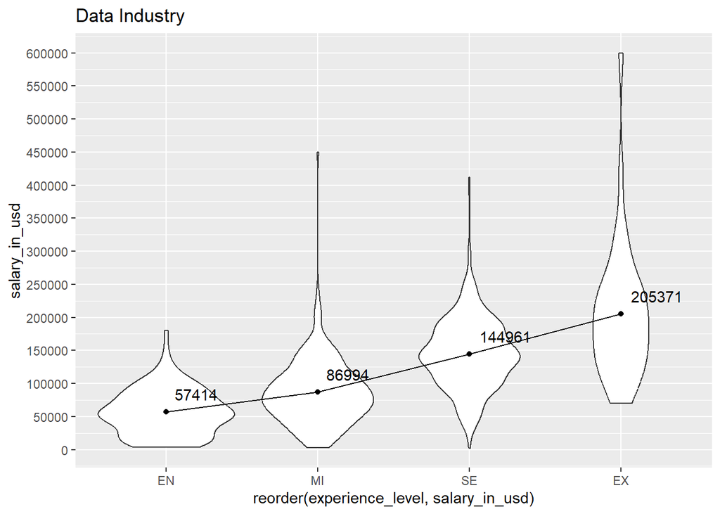

```r
custom_line_plot <- function(datos,avgs, title){
  plot1 <- ggplot()+
            geom_violin(data=datos, aes(x=reorder(experience_level,salary_in_usd), y = salary_in_usd))+
  geom_line(data=avgs,aes(x=Experience_Level, y=Average_Salary, group=1))+
  geom_point(data=avgs,aes(x=Experience_Level, y=Average_Salary, group=1))+
  geom_text(data=avgs,aes(x=Experience_Level, y=Average_Salary, label = round(Average_Salary,0)) ,hjust=-0.2, vjust=-1)+
  scale_y_continuous(breaks = scales::pretty_breaks(n = 15))+
  labs(title=title)
  plot1
}

custom_line_plot(df_data,data_avg,"Data Industry")
```

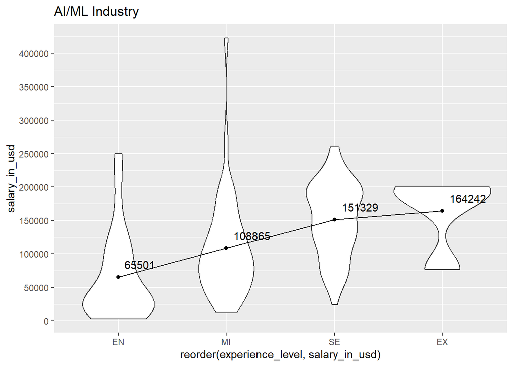

```r
custom_line_plot(df_ai,ai_avg,"AI/ML Industry")
```

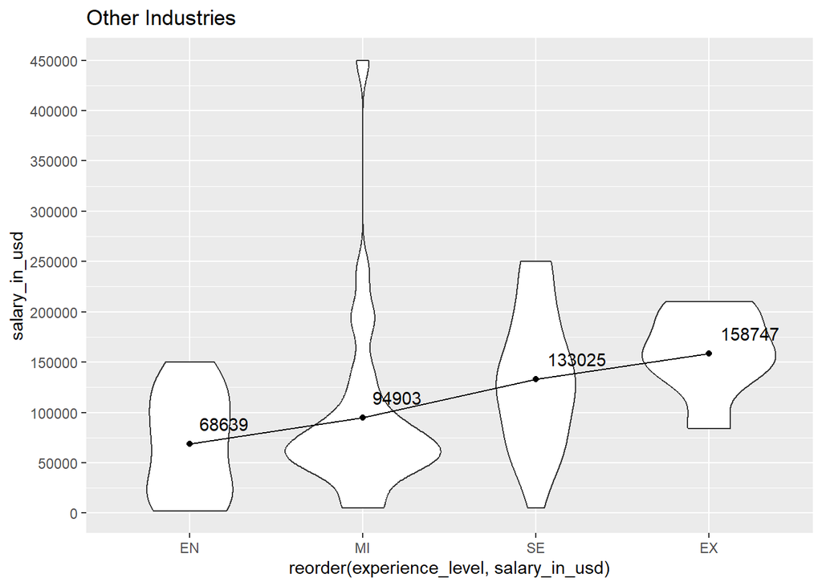

```r
custom_line_plot(df_other, other_avg,"Other Industries")
```

```r
get_increases <- function(dframe){
  dframe$increase <- 0
dframe$increase[dframe$Experience_Level=="MI"] <- dframe$Average_Salary[dframe$Experience_Level=="MI"] - dframe$Average_Salary[dframe$Experience_Level=="EN"]
dframe$increase[dframe$Experience_Level=="SE"] <- dframe$Average_Salary[dframe$Experience_Level=="SE"] - dframe$Average_Salary[dframe$Experience_Level=="MI"]
dframe$increase[dframe$Experience_Level=="EX"] <- dframe$Average_Salary[dframe$Experience_Level=="EX"] - dframe$Average_Salary[dframe$Experience_Level=="SE"]

dframe$increasePercentage <- 0
dframe$increasePercentage[dframe$Experience_Level=="MI"] <- dframe$Average_Salary[dframe$Experience_Level=="MI"] / dframe$Average_Salary[dframe$Experience_Level=="EN"]
dframe$increasePercentage[dframe$Experience_Level=="SE"] <- dframe$Average_Salary[dframe$Experience_Level=="SE"] / dframe$Average_Salary[dframe$Experience_Level=="MI"]
dframe$increasePercentage[dframe$Experience_Level=="EX"] <- dframe$Average_Salary[dframe$Experience_Level=="EX"] / dframe$Average_Salary[dframe$Experience_Level=="SE"]

dframe$increasePercentage <- ifelse(dframe$Experience_Level=="EN",0,(dframe$increasePercentage - 1) * 100)

return(dframe)
}

data_avg <- get_increases(data_avg)
ai_avg <- get_increases(ai_avg)
other_avg <- get_increases(other_avg)

data_avg
```

```
##   Experience_Level Average_Salary increase increasePercentage
## 1               EN       57413.78     0.00            0.00000
## 2               MI       86994.15 29580.37           51.52138
## 3               SE      144961.30 57967.15           66.63339
## 4               EX      205371.24 60409.94           41.67315
```

```r
ai_avg
```

```
##   Experience_Level Average_Salary increase increasePercentage
## 1               EN        65501.3     0.00           0.000000
## 2               MI       108864.9 43363.55          66.202585
## 3               SE       151329.1 42464.23          39.006374
## 4               EX       164241.8 12912.66           8.532837
```

```r
other_avg
```

```
##   Experience_Level Average_Salary increase increasePercentage
## 1               EN       68638.79     0.00            0.00000
## 2               MI       94903.37 26264.58           38.26493
## 3               SE      133025.39 38122.02           40.16930
## 4               EX      158747.00 25721.61           19.33586
```

### 2. What is more worth, to work in the office at your region or remotely in another region?

First we should have a look at how much are employees paid while working in the office at their same region.

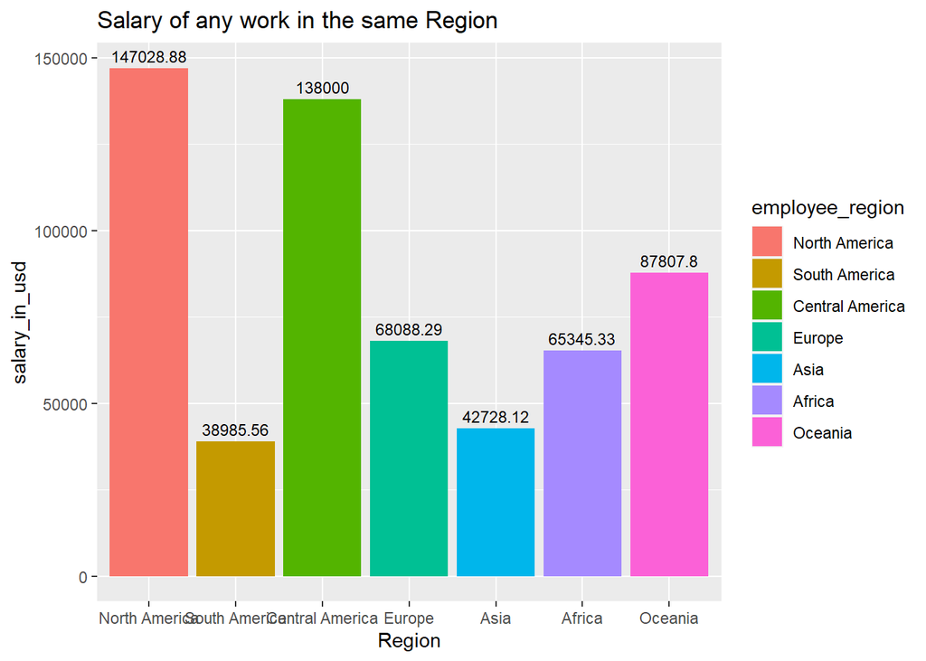

```r
df_filtered <- filter(df, employee_region == company_region)

print(ggplot(aes(x = employee_region, y = salary_in_usd, fill=employee_region), data = df_filtered) +
    stat_summary(fun=mean, geom="bar", position = "stack") +
    stat_summary(aes(label=round(after_stat(y),2)), fun.y=mean, geom="text", size=3, vjust = -0.5) +
    xlab("Region") + labs(title="Salary of any work in the same Region"))
```

Could they earn more if they work remotely for another Region?

Lets have a look at how much do companies in each region pay for Remote work.

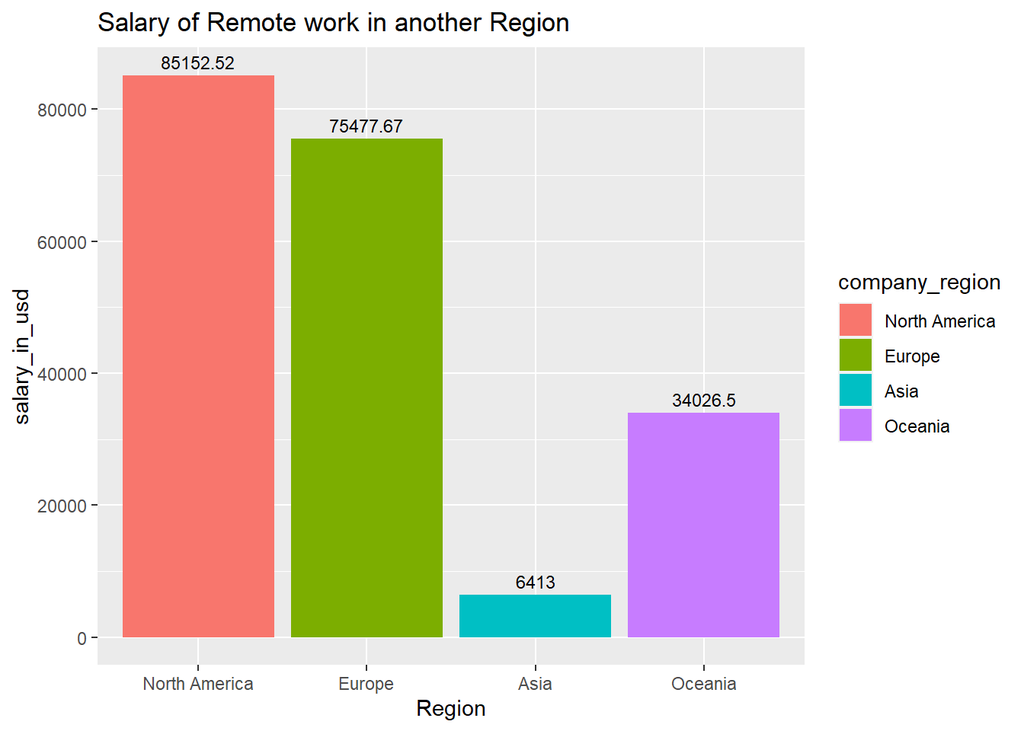

```r
df_filtered <- filter(df, employee_region != company_region & remote_ratio == "Remote")

print(ggplot(aes(x = company_region, y = salary_in_usd, fill=company_region), data = df_filtered) +
    stat_summary(fun=mean, geom="bar", position = "stack") +
    stat_summary(aes(label=round(after_stat(y),2)), fun.y=mean, geom="text", size=3, vjust = -0.5) +
    xlab("Region") + labs(title="Salary of Remote work in another Region"))
```

We can see that by average North America and Europe are close, while the rest are much lower, especially Asia. The regions that do not appear, don’t employ remote workers from another regions.

In relation to the high paying, we can see that USA pays less for remote work, than for office work. On the other hand in Europe the salary is on the same level for remote and office work.

Now we can focus on answering the question.

```r
aux <- data.frame(matrix(0, nrow = length(levels(df$company_region)), ncol = length(levels(df$company_region))))
colnames(aux) <- levels(df$company_region)
rownames(aux) <- levels(df$company_region)

for (i in 1:nrow(aux)) {
  max = 0
  for (j in 1:ncol(aux)) {
    df_filtered <- filter(df, company_region == colnames(aux)[j] & employee_region == rownames(aux)[i])
    aux[i, j] <- mean(df_filtered$salary_in_usd)
  }
}

aux_clean <- data.frame(matrix(0, nrow = length(levels(df$company_region)), ncol = length(levels(df$company_region))))
colnames(aux_clean) <- levels(df$company_region)
rownames(aux_clean) <- levels(df$company_region)

aux <- replace(aux, is.na(aux), 0)

for (i in 1:nrow(aux_clean)) {
  max <- 0
  for (j in 1:ncol(aux_clean)) {
    #if(i == j) {
     # aux_clean[i,j] <- aux[i,j]
    #} else
    if(aux[i,j]>max){
      max <- aux[i,j]
      aux_clean[i,j] <- aux[i,j]
    }
  }
}


data_long <- aux_clean %>%
  rownames_to_column %>%
  gather(key = 'key', value = 'value', -rowname) %>%
  filter(value > 0)
colnames(data_long) <- c("source", "target", "value")
data_long$target <- paste(data_long$target, " ", sep="")

nodes <- data.frame(name=c(as.character(data_long$source), as.character(data_long$target)) %>% unique())

data_long$IDsource=match(data_long$source, nodes$name)-1
data_long$IDtarget=match(data_long$target, nodes$name)-1

sankeyNetwork(Links = data_long, Nodes = nodes,
                     Source = "IDsource", Target = "IDtarget",
                     Value = "value", NodeID = "name",
                     sinksRight=FALSE, nodeWidth=40, fontSize=13, nodePadding=20)
```

[interactive chart not shown]

In the plot above we can see on the left the employee region and on the right the company region where is more worth to work for them. The dataset is pretty unbalanced in general, some regions have very few entries and many of them are not representative compared to the rest of the data or other regions.

So we can conclude that with the current data is not possible to give a sensible answer for all of the regions and we would need to expand the dataset and balance the different regions and remote types.

### 3. Can the salary increase between 2021 and 2022 be explained by inflation?

```r
increase = (mean(df[df$work_year == 2022, 'salary_in_usd'])/mean(df[df$work_year == 2021, 'salary_in_usd'])) - 1
net_increase = increase - 0.077 # official inflation rate in 2022 in the US
net_increase
```

```
## [1] 0.2717521
```

It seems like the increase in salaries between 2021 and 2022 is not explained only with the inflation, since the increase has been of over a 34% in total and the official 2022 inflation rate that the US government gives is ay 7.7%. The net salary increase taking that into account (most samples of the data are US based), net salaries have increased a 27.17%.

### 4. Join cost of living index dataset into problem dataset

We only want the country and the cost of living and we delete Kosovo from the list since it is a disputed territory and luckily enough we don’t have any Kosovo related data in our dataset

```r
cost_of_living_df = read.csv("Cost_of_Living_Index_2022.csv", stringsAsFactors = TRUE)[-67, c(2,3)]
cost_of_living_df = setNames(cost_of_living_df, c("country", "cost_of_living_index"))
cost_of_living_df$country = countrycode(cost_of_living_df$country, origin = 'country.name', destination = 'iso2c')
```

Add the cost of living index columns of the employee residence and the company location deleting those rows that contain either American Samoa or Aaland Islands, since we don’t have information about the cost of living index in these countries.

```r
dfN<-subset(df, employee_residence!="AX" & employee_residence!="AS" & company_location!="AX" & company_location!="AS")
dfN$cost_of_living_index_employee = rep(0, nrow(dfN))
dfN$cost_of_living_index_company = rep(0, nrow(dfN))
for(i in 1:nrow(dfN)) {
  country_employee = dfN[i, ]$employee_residence
  country_company = dfN[i, ]$company_location
  index_employee =  cost_of_living_df[as.character(cost_of_living_df$country)==as.character(country_employee), ]$cost_of_living_index
  index_company = cost_of_living_df[as.character(cost_of_living_df$country)==as.character(country_company), ]$cost_of_living_index
  dfN[i,]$cost_of_living_index_employee = index_employee
  dfN[i,]$cost_of_living_index_company = index_company
}
```

```r
subset(dfN, cost_of_living_index_employee>cost_of_living_index_company)
```

```
##      work_year experience_level employment_type                          job_title salary_currency salary_in_usd employee_residence remote_ratio company_location company_size salary_group employee_region company_region industry      role  boss research cost_of_living_index_employee cost_of_living…
## 439       2022               EN              FT                     Data Scientist             USD         50000                 US       Hybrid               DE            M          50k   North America         Europe     DATA SCIENTIST FALSE    FALSE                         70.13               …
## 440       2022               EN              FT                       Data Analyst             INR          6413                 FR       Remote               IN            L          25k          Europe           Asia     DATA   ANALYST FALSE    FALSE                         74.13               …
## 643       2022               SE              FT Applied Machine Learning Scientist             EUR         77280                 FR       Remote               GB            L         100k          Europe         Europe    ML/AI SCIENTIST FALSE    FALSE                         74.13               …
## 745       2022               MI              FT          Machine Learning Engineer             EUR         84229                 FR       Remote               DE            M         100k          Europe         Europe    ML/AI  ENGINEER FALSE    FALSE                         74.13               …
## 1015      2022               EN              FT                     Data Scientist             USD         40000                 JP       Remote               MY            L          50k            Asia           Asia     DATA SCIENTIST FALSE    FALSE                         77.03               …
## 1051      2022               MI              FL                     Data Scientist             USD        100000                 CA       Remote               US            M         100k   North America  North America     DATA SCIENTIST FALSE    FALSE                         70.22               …
## 1073      2021               MI              FT                  Big Data Engineer             USD         60000                 ES       Hybrid               RO            M          75k          Europe         Europe     DATA  ENGINEER FALSE    FALSE                         53.88               …
## 1113      2021               EX              FT           Director of Data Science             EUR        153667                 IT       Remote               PL            L         200k          Europe         Europe     DATA     OTHER  TRUE    FALSE                         66.47               …
## 1194      2021               EN              FT                 Research Scientist             USD        100000                 JE       Office               CN            L         100k          Europe           Asia    OTHER SCIENTIST FALSE     TRUE                         92.02               …
## 1202      2021               EN              FT          Machine Learning Engineer             USD         85000                 NL       Remote               DE            S         100k          Europe         Europe    ML/AI  ENGINEER FALSE    FALSE                         75.66               …
## 1233      2021               EX              FT            Data Science Consultant             EUR         69741                 FR       Remote               ES            S          75k          Europe         Europe     DATA     OTHER FALSE    FALSE                         74.13               …
## 1268      2021               MI              FT                      Data Engineer             GBP         66022                 HK       Hybrid               GB            S          75k            Asia         Europe     DATA  ENGINEER FALSE    FALSE                         80.71               …
## 1277      2021               SE              FT                 Research Scientist             USD         50000                 FR       Remote               US            S          50k          Europe  North America    OTHER SCIENTIST FALSE     TRUE                         74.13               …
```

```r
subset(dfN, as.character(company_location)!=as.character(employee_residence))
```

```
##      work_year experience_level employment_type                          job_title salary_currency salary_in_usd employee_residence remote_ratio company_location company_size salary_group employee_region company_region industry      role  boss research cost_of_living_index_employee cost_of_living…
## 68        2022               EN              PT                       Data Analyst             USD        125404                 CN       Hybrid               US            S         150k            Asia  North America     DATA   ANALYST FALSE    FALSE                         41.77               …
## 157       2022               SE              FT             Product Data Scientist             USD          8000                 IN       Remote               SG            L          25k            Asia           Asia     DATA SCIENTIST FALSE    FALSE                         24.43               …
## 271       2022               EN              FT                       Data Analyst             USD         20000                 CR       Hybrid               US            M          25k Central America  North America     DATA   ANALYST FALSE    FALSE                         47.01               …
## 315       2022               EN              FT                    Data Specialist             USD        105000                 CL       Remote               US            L         125k   South America  North America     DATA     OTHER FALSE    FALSE                         43.90               …
## 357       2022               EN              FT                       AI Scientist             EUR         31586                 PT       Remote               ES            M          50k          Europe         Europe    ML/AI SCIENTIST FALSE    FALSE                         47.94               …
## 373       2022               MI              CT                       NLP Engineer             USD         60000                 IN       Remote               US            S          75k            Asia  North America    OTHER  ENGINEER FALSE    FALSE                         24.43               …
## 403       2022               SE              FT           Data Engineering Manager             USD        193000                 ES       Remote               US            M         200k          Europe  North America     DATA   MANAGER FALSE    FALSE                         53.88               …
## 439       2022               EN              FT                     Data Scientist             USD         50000                 US       Hybrid               DE            M          50k   North America         Europe     DATA SCIENTIST FALSE    FALSE                         70.13               …
## 440       2022               EN              FT                       Data Analyst             INR          6413                 FR       Remote               IN            L          25k          Europe           Asia     DATA   ANALYST FALSE    FALSE                         74.13               …
## 500       2022               MI              FT Applied Machine Learning Scientist             USD         75000                 BO       Remote               US            M          75k   South America  North America    ML/AI SCIENTIST FALSE    FALSE                         34.77               …
## 538       2022               EN              PT                     Data Scientist             USD        110000                 DO       Remote               FR            M         125k Central America         Europe     DATA SCIENTIST FALSE    FALSE                         41.77               …
## 631       2022               MI              FT                     Data Scientist             INR         53877                 IN       Remote               ID            L          75k            Asia           Asia     DATA SCIENTIST FALSE    FALSE                         24.43               …
## 636       2022               SE              FT                 Analytics Engineer             USD         48000                 AR       Remote               US            S          50k   South America  North America    OTHER  ENGINEER FALSE    FALSE                         34.69               …
## 643       2022               SE              FT Applied Machine Learning Scientist             EUR         77280                 FR       Remote               GB            L         100k          Europe         Europe    ML/AI SCIENTIST FALSE    FALSE                         74.13               …
```

[output cut: 50 more lines]